# Моментум-стратегии и reality check Индия (данные с нулями)

> Количество исследумых компаний – **200**

> Период отслеживания менялся от **1** до **12** месяцев

> Период ожидания менялся от **0** до **8** недель

> Период инвестирования менялся от **1** до **12** месяцев

## 1. Моментум стратегии при равных весах. Ранжирование по средней доходности (бенчмарк 6% годовых - только для reality check)

> Всего было рассмотрено **5184** стратегий

#### **Таблица 1. Все стратегии**

|  | mean | t | p-value | hist_per | moment_per | invest_per | percent | Amount_of_negative |
| --- | --- | --- | --- | --- | --- | --- | --- | --- |
| 1 | 0.001829 | 0.588371 | 0.55779 | 4 | 0 | 4 | 0.5 | 38 |
| 2 | 0.004139 | 1.505968 | 0.135657 | 4 | 0 | 8 | 0.5 | 38 |
| 3 | 0.003189 | 1.515447 | 0.133243 | 4 | 0 | 12 | 0.5 | 31 |
| 4 | 0.000865 | 0.425184 | 0.67174 | 4 | 0 | 16 | 0.5 | 36 |
| 5 | 0.001631 | 0.972604 | 0.333416 | 4 | 0 | 20 | 0.5 | 36 |
| 6 | 0.003133 | 2.261074 | 0.02622 | 4 | 0 | 24 | 0.5 | 35 |
| 7 | 0.003851 | 2.94532 | 0.004127 | 4 | 0 | 28 | 0.5 | 33 |
| 8 | 0.00448 | 3.424674 | 0.000937 | 4 | 0 | 32 | 0.5 | 32 |
| 9 | 0.00434 | 3.303151 | 0.001383 | 4 | 0 | 36 | 0.5 | 34 |
| 10 | 0.003475 | 2.651745 | 0.009497 | 4 | 0 | 40 | 0.5 | 33 |

[output cut: 5174 more lines]

#### **Рисунок 1.**

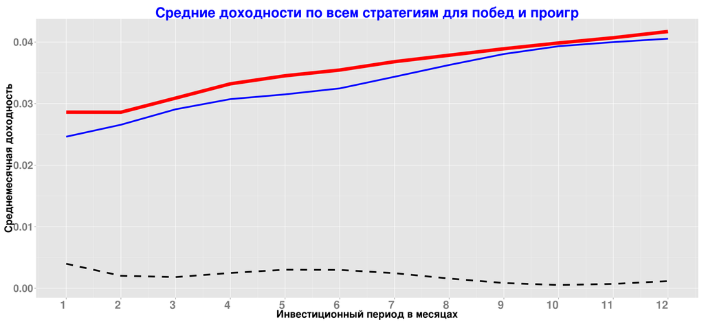

#### **Таблица 2. Агрегированные по всем стратегиям доходности победителей и проигравших**

|  | invest.per | aggr.winner | aggr.loser | delta |
| --- | --- | --- | --- | --- |
| 1 | 1 | 0.0286 | 0.0246 | 0.004 |
| 2 | 2 | 0.0286 | 0.0266 | 0.002 |
| 3 | 3 | 0.0309 | 0.0291 | 0.0018 |
| 4 | 4 | 0.0332 | 0.0307 | 0.0025 |
| 5 | 5 | 0.0345 | 0.0315 | 0.003 |
| 6 | 6 | 0.0355 | 0.0325 | 0.003 |
| 7 | 7 | 0.0368 | 0.0344 | 0.0025 |
| 8 | 8 | 0.0379 | 0.0363 | 0.0016 |
| 9 | 9 | 0.0389 | 0.038 | 0.0009 |
| 10 | 10 | 0.0398 | 0.0393 | 0.0005 |

[output cut: 2 more lines]

> Лучшая по средней доходности стратегия дает среднемесячную доходность **1.55** **%** и имеет параметры: период отбора – **8** месяцев, период ожидания – **0** недель, период инвестирования – **1** месяцев, процентиль – **0.1**

> Bootstrap p-value равен **0.81**

> Всего портфелей у лучшей стратегии – **89** Количество отрицательных доходностей у лучшей стратегии – **32** ( **35.96%** )

#### **Рисунок 2.**

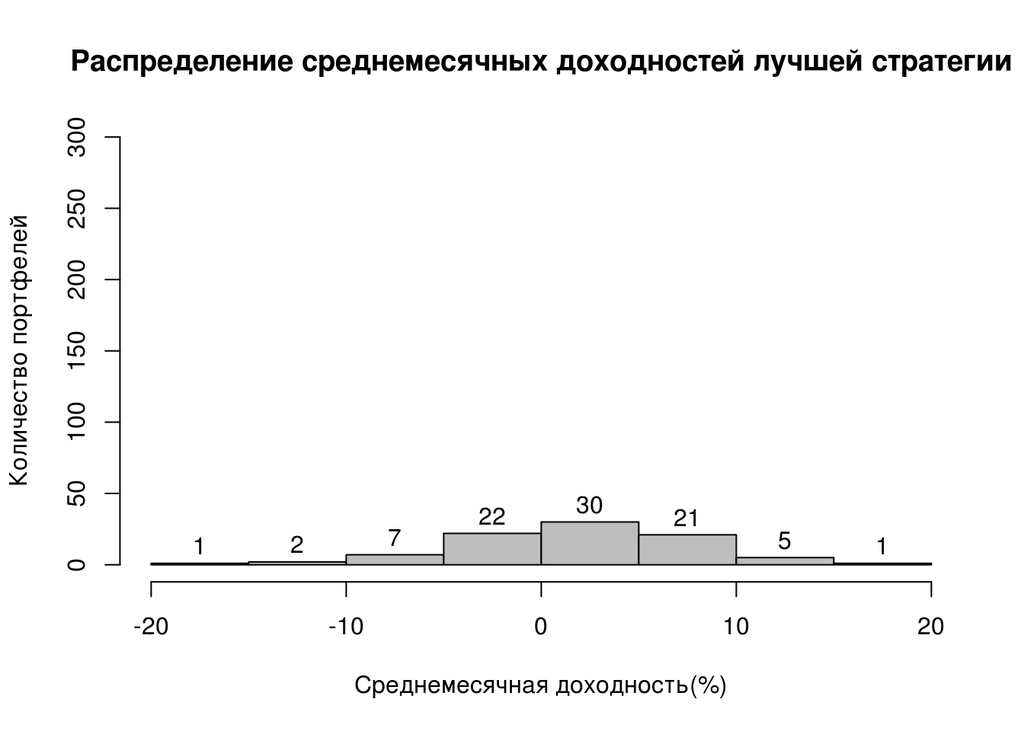

#### **Рисунок 3. (вертикальные пунктирные линии - начало нового года)**

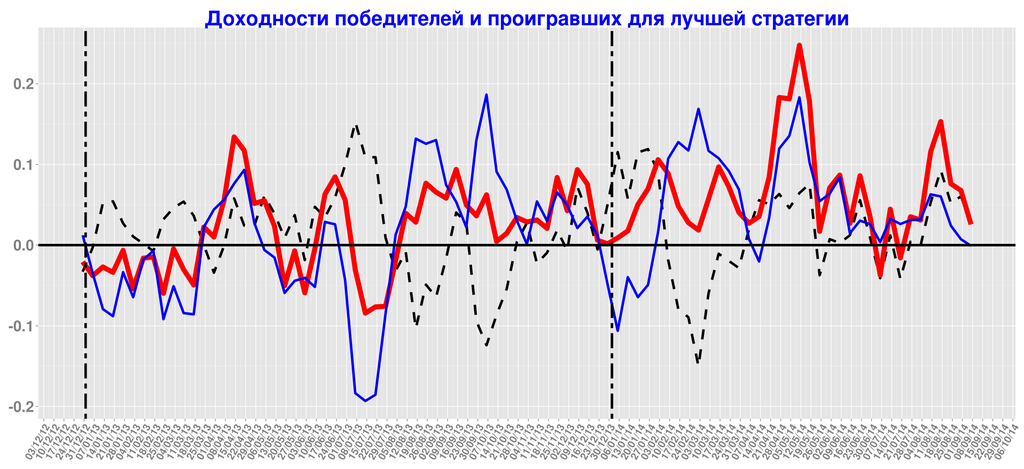

#### **Таблица 3. Доходности победителей и проигравших для лучшей стратегии**

|  | date | Win_portf | Los_portf | Win_Los |
| --- | --- | --- | --- | --- |
| 1 | 2012-12-30 | -0.0207 | 0.0122 | -0.0329 |
| 2 | 2013-01-06 | -0.0379 | -0.0352 | -0.0027 |
| 3 | 2013-01-13 | -0.0271 | -0.0793 | 0.0522 |
| 4 | 2013-01-20 | -0.0338 | -0.0881 | 0.0542 |
| 5 | 2013-01-27 | -0.0065 | -0.0336 | 0.027 |
| 6 | 2013-02-03 | -0.054 | -0.0646 | 0.0106 |
| 7 | 2013-02-10 | -0.0162 | -0.0181 | 0.0019 |
| 8 | 2013-02-17 | -0.0145 | -0.007 | -0.0075 |
| 9 | 2013-02-24 | -0.0598 | -0.0918 | 0.032 |
| 10 | 2013-03-03 | -0.0047 | -0.0509 | 0.0462 |

[output cut: 79 more lines]

### **Вхождение в победителей и проигравших для лучшей стратегии**

#### **Рисунок 4.**

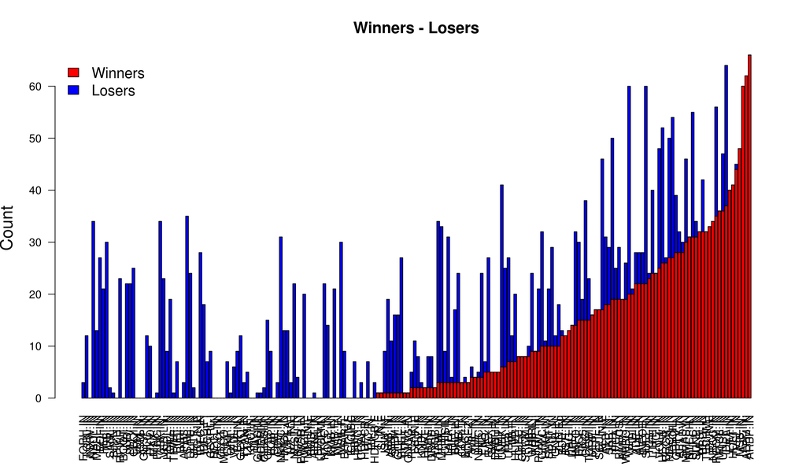

#### **Рисунок 5.**

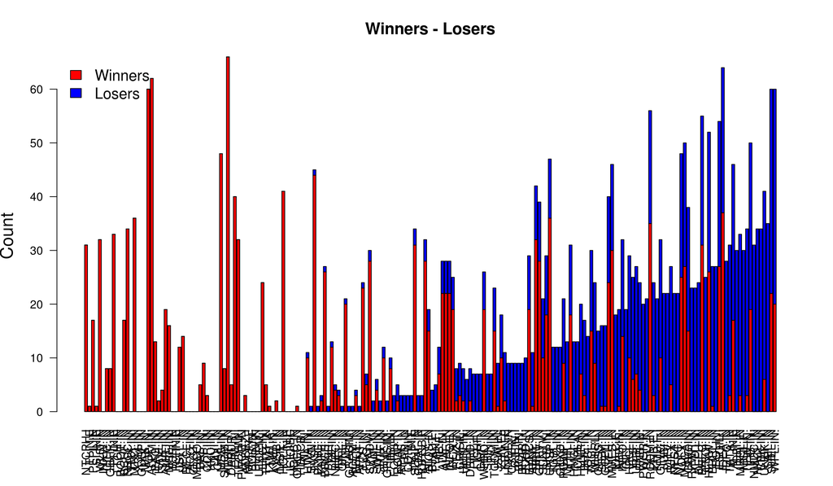

#### **Таблица 4. Вхождение компаний в победители и проигравшие для лучшей по средней доходности стратегии**

|  | Ticket | In_winners | In_losers |
| --- | --- | --- | --- |
| 1 | HEXW.IN.Equity | 26 | 26 |
| 2 | FAG.IN.Equity | 5 | 2 |
| 3 | FORH.IN.Equity | 0 | 3 |
| 4 | TPW.IN.Equity | 3 | 31 |
| 5 | TGBL.IN.Equity | 0 | 12 |
| 6 | TRCL.IN.Equity | 15 | 15 |
| 7 | NTCPH.IN.Equity | 31 | 0 |
| 8 | TI.IN.Equity | 1 | 0 |
| 9 | GFLC.IN.Equity | 10 | 22 |
| 10 | PEPL.IN.Equity | 17 | 0 |

[output cut: 190 more lines]

## 2. Моментум стратегии при равных весах. Ранжирование по t-статистике (бенчмарк 6% годовых - только для reality check)

> Лучшая по t-статистике стратегия дает среднемесячную доходность **0.9** **%** и имеет параметры: период отбора – **5** месяцев, период ожидания – **1** недель, период инвестирования – **5** месяцев, процентиль – **0.2**

> Bootstrap p-value равен **0.868**

> Всего портфелей у лучшей по t-статистике стратегии – **89** Количество отрицательных доходностей у лучшей по t-статистике стратегии – **28** ( **31.46%** )

#### **Рисунок 6.**

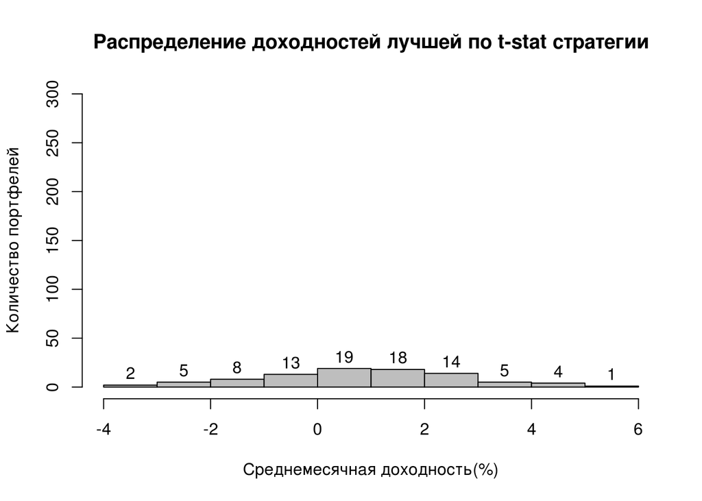

#### **Рисунок 7. (вертикальные пунктирные линии - начало нового года)**

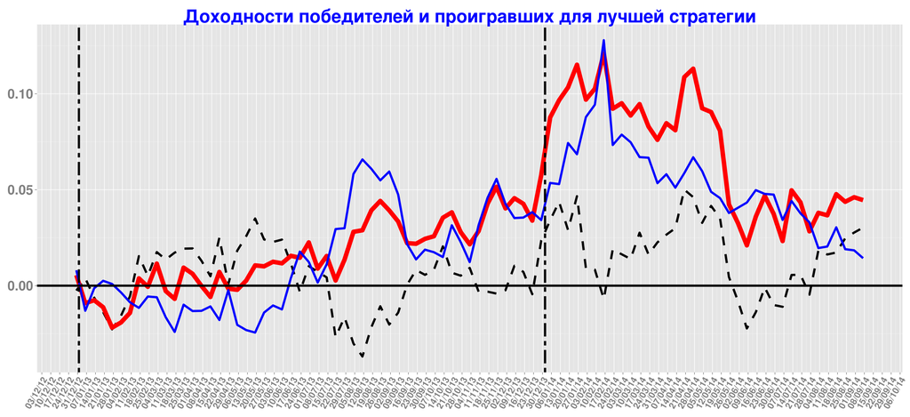

#### **Таблица 5. Доходности победителей и проигравших для лучшей стратегии**

|  | date | Win_portf | Los_portf | Win_Los |
| --- | --- | --- | --- | --- |
| 1 | 2012-12-30 | 0.0055 | 0.0081 | -0.0025 |
| 2 | 2013-01-06 | -0.0091 | -0.0131 | 0.0039 |
| 3 | 2013-01-13 | -0.0076 | -0.0013 | -0.0062 |
| 4 | 2013-01-20 | -0.0112 | 0.0025 | -0.0138 |
| 5 | 2013-01-27 | -0.0219 | 0.0009 | -0.0228 |
| 6 | 2013-02-03 | -0.0192 | -0.0035 | -0.0156 |
| 7 | 2013-02-10 | -0.0142 | -0.0087 | -0.0055 |
| 8 | 2013-02-17 | 0.0038 | -0.0116 | 0.0154 |
| 9 | 2013-02-24 | -0.0006 | -0.0057 | 0.0051 |
| 10 | 2013-03-03 | 0.0115 | -0.006 | 0.0175 |

[output cut: 79 more lines]

### **Вхождение в победителей и проигравших для лучшей стратегии**

#### **Рисунок 8.**

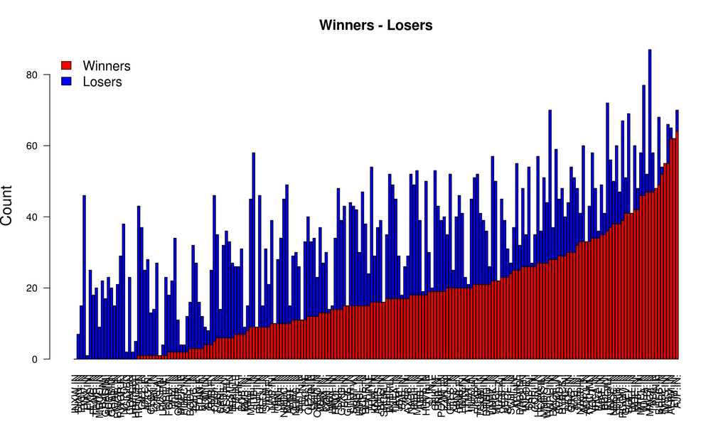

#### **Рисунок 9.**

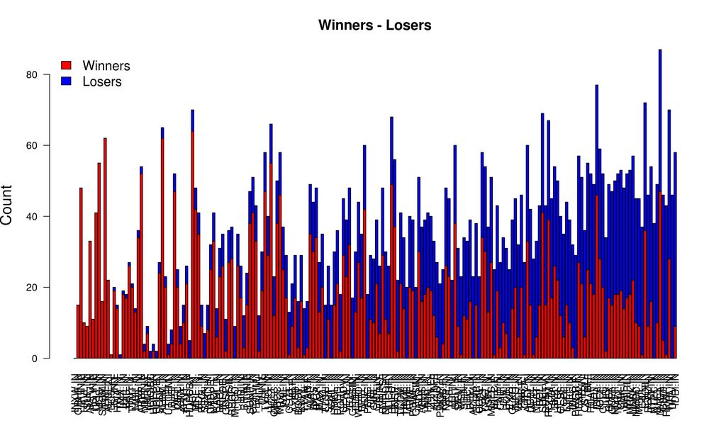

#### **Таблица 6. Вхождение компаний в победители и проигравшие для лучшей по t-статистике стратегии**

|  | Ticket | In_winners | In_losers |
| --- | --- | --- | --- |
| 1 | HEXW.IN.Equity | 27 | 30 |
| 2 | FAG.IN.Equity | 20 | 15 |
| 3 | FORH.IN.Equity | 2 | 16 |
| 4 | TPW.IN.Equity | 16 | 38 |
| 5 | TGBL.IN.Equity | 6 | 29 |
| 6 | TRCL.IN.Equity | 26 | 22 |
| 7 | NTCPH.IN.Equity | 33 | 8 |
| 8 | TI.IN.Equity | 19 | 11 |
| 9 | GFLC.IN.Equity | 20 | 32 |
| 10 | PEPL.IN.Equity | 17 | 18 |

[output cut: 190 more lines]